# E. coli - Gestion de données non structurées - Applications post-génomiques - Mise en oeuvre

Roland Barriot

15 octobre, 2021

```r
#knitr::opts_chunk$set(echo = TRUE)
options(width = 120) # nombre de colonnes pour l'affichage sur la sorties HTML
# knitr::opts_chunk$set(cache=F)
# knitr::opts_chunk$set(fig.width=6, fig.height=6) # for rstudio
# knitr::opts_chunk$set(fig.width=14, fig.height=14) # for html
```

```r
library(jsonlite)
library(tidyverse)
library(reticulate)
library(STRINGdb)
library(DT)
library(tibble)
library(readr)
library(kableExtra)
library(igraph)
```

```r
uniprot = read_tsv("ecoli/uniprot-proteome_UP000000625.tab")
mapping = uniprot %>%
  select(Entry, names = `Gene names  (ordered locus )`) %>%
  mutate(bnumber=str_extract(names, 'b\\d+')) %>%
  select(bnumber, uniprotID=Entry) %>%
  filter(!is.na(bnumber)) %>% # 2021 → P0DQD7 and P0A6D5 are lost (no bnumber)
  arrange(bnumber)
keywords = uniprot %>%
  select(uniprotID=Entry, keyword=Keywords) %>%
  right_join(mapping) %>% # right join to remove those without bnumber
  separate_rows(keyword, sep=';') %>%
  select(bnumber, keyword) %>%
  arrange(bnumber)
```

```r
ref_sets = keywords %>%
  group_by(keyword) %>%
  summarise(count=n(), elements = list(bnumber)) %>%
  ungroup %>%
  filter(count>1)  %>%
  select(id=keyword, desc=count, elements)
ref_sets
```

| id | desc | elements |
| --- | --- | --- |
| 2Fe-2S | 24 |  |
| 3D-structure | 1571 |  |
| 3Fe-4S | 7 |  |
| 4Fe-4S | 112 |  |
| Acetylation | 100 |  |
| Activator | 116 |  |
| Acyltransferase | 68 |  |
| ADP-ribosylation | 4 |  |
| Allosteric enzyme | 38 |  |
| Alternative initiation | 7 |  |

[output cut: 323 more lines]

```r
ref_sets %>% toJSON %>% write("reference.sets/uniprot.keywords.sets.json")
```

[output not shown]

[output cut: 990 more lines]

```r
if (!require('neo4r')) { # client neo4j
  install.packages('neo4r')
}
library(neo4r)
neodb = neo4j_api$new(
  url = "http://localhost:7474",
  user = "neo4j",
  password = "a"
)
cypher = function(query, neo4j=neodb, ...) call_neo4j(query=query, con=neo4j, ...)
```

```r
genes = read_tsv("neo.data/ncbi.bnumber.location.tsv")
```

[output not shown]

Client R

```r
kabex = function(o) o %>% kable(format="html", escape=F) %>% kable_styling(bootstrap_options = c("striped"))

dted = function(o) o %>% datatable(rownames=F, filter="top", options=list(pageLength = 10), escape=F)
```

Connexion au serveur de STRING (NCBI taxon id de Ecoli est 511145: https://string-db.org/cgi/input.pl?input_page_active_form=organism )

```r
confidence_threshold = 333
stringdb = STRINGdb$new(version='11', species=511145, score_threshold=confidence_threshold, input_directory='stringdb')
```

Téléchargement du génome/protéome :

```r
proteins = stringdb$get_proteins() %>% as_tibble
proteins %>% dted
```

| protein_external_id | preferred_name | protein_size | annotation |
| --- | --- | --- | --- |
| 511145.b0001 | thrL | 21 | Thr operon leader peptide; This protein is involved in control of the biosynthesis of threonine |
| 511145.b0002 | thrA | 820 | Bifunctional: aspartokinase I (N-terminal); homoserine dehydrogenase I (C-terminal); Protein involved in threonine biosynthetic process, methionine biosynthetic process and homoserine biosynthetic pro… |
| 511145.b0003 | thrB | 310 | Homoserine kinase; Catalyzes the ATP-dependent phosphorylation of L- homoserine to L-homoserine phosphate. Is also able to phosphorylate the hydroxy group on gamma-carbon of L-homoserine analogs when … |
| 511145.b0004 | thrC | 428 | Threonine synthase; Catalyzes the gamma-elimination of phosphate from L- phosphohomoserine and the beta-addition of water to produce L- threonine. To a lesser extent, is able to slowly catalyze the de… |
| 511145.b0005 | yaaX | 98 | annotation not available |
| 511145.b0006 | yaaA | 258 | annotation not available |
| 511145.b0007 | yaaJ | 476 | Uncharacterized transporter YaaJ; Inner membrane transport protein |
| 511145.b0008 | talB | 317 | Transaldolase B; Transaldolase is important for the balance of metabolites in the pentose-phosphate pathway |
| 511145.b0009 | mog | 195 | Molybdopterin adenylyltransferase; Catalyzes the adenylation of molybdopterin as part of the biosynthesis of the molybdenum-cofactor; Belongs to the MoaB/Mog family |
| 511145.b0010 | satP | 188 | Succinate-acetate/proton symporter SatP; Uptake of acetate and succinate. Transport is energetically dependent on the protonmotive force |

[output cut: 4117 more lines]

### Données de coexpression

Nous allons utiliser les données d’expression déjà intégrées dans STRINGdb. Il est bien sûr possible de calculer un score de co-expression entre les paires de gènes à partir de données de microarray et/ou RNAseq.

### STRINGdb detailed links → neo4j

Il faut passer par la page de téléchargement sur https://string-db.org/cgi/download.pl en restreignant l’organisme d’intérêt.

Le fichier complet faisant ~150Go (au 15/10/2021), il est conseillé de d’abord sélectionner un organisme avant le téléchargement (~10Mo pour *E. coli*). Une copie est disponible sur silico à récupérer sur http://silico.biotoul.fr/enseignement/m2bbs/idh/2021/

Qu’y a-t-il dedans ? shell:

```bash
zcat stringdb/511145.protein.links.detailed.v11.5.txt.gz | head
```

Chargement de set.01.txt pour analyse.

```r
s1 = scan('sets/set_01.txt', character())
```

```
Read 181 items
```

```r
s1
```

```
  [1] "b0001" "b0002" "b0003" "b0004" "b0031" "b0032" "b0033" "b0071" "b0072" "b0073"
 [11] "b0074" "b0075" "b0077" "b0078" "b0159" "b0166" "b0242" "b0243" "b0261" "b0273"
 [21] "b0386" "b0388" "b0529" "b0674" "b0754" "b0907" "b0908" "b1260" "b1261" "b1262"
 [31] "b1263" "b1264" "b1265" "b1275" "b1622" "b1693" "b1704" "b2018" "b2019" "b2020"
 [41] "b2021" "b2022" "b2023" "b2024" "b2025" "b2026" "b2329" "b2413" "b2414" "b2421"
 [51] "b2472" "b2478" "b2551" "b2599" "b2600" "b2601" "b2763" "b2764" "b2818" "b2838"
 [61] "b2913" "b3008" "b3172" "b3212" "b3213" "b3237" "b3281" "b3359" "b3389" "b3390"
 [71] "b3433" "b3607" "b3670" "b3671" "b3672" "b3744" "b3766" "b3769" "b3770" "b3771"
 [81] "b3772" "b3773" "b3774" "b3809" "b3828" "b3829" "b3938" "b3939" "b3940" "b3941"
 [91] "b3957" "b3958" "b3959" "b3960" "b4013" "b4019" "b4024" "b4054" "b4243" "b4254"
[101] "b4388" "b4488" "b0112" "b0197" "b0198" "b0199" "b0401" "b0402" "b0486" "b0576"
[111] "b0652" "b0653" "b0654" "b0655" "b0692" "b0809" "b0810" "b0811" "b0813" "b0860"
[121] "b0861" "b0862" "b0863" "b0864" "b0874" "b1015" "b1296" "b1336" "b1453" "b1473"
[131] "b1492" "b1533" "b1605" "b1729" "b1798" "b1907" "b1917" "b1918" "b1920" "b2014"
[141] "b2128" "b2129" "b2130" "b2131" "b2156" "b2306" "b2307" "b2308" "b2309" "b2310"
[151] "b2365" "b2578" "b2663" "b2670" "b2677" "b2678" "b2679" "b2923" "b3089" "b3110"
[161] "b3116" "b3161" "b3268" "b3269" "b3270" "b3271" "b3370" "b3454" "b3455" "b3456"
[171] "b3457" "b3458" "b3460" "b3653" "b3709" "b3795" "b4077" "b4115" "b4132" "b4141"
[181] "b4208"
```

Mapping des identifiants vers ceux de StringDB

```r
s1.mapped = stringdb$mp(s1)
s1.mapped
```

```
  [1] "511145.b0001" "511145.b0002" "511145.b0003" "511145.b0004" "511145.b0031"
  [6] "511145.b0032" "511145.b0033" "511145.b0071" "511145.b0072" "511145.b0073"
 [11] "511145.b0074" "511145.b0075" "511145.b0077" "511145.b0078" "511145.b0159"
 [16] "511145.b0166" "511145.b0242" "511145.b0243" "511145.b0261" "511145.b0273"
 [21] "511145.b0386" "511145.b0388" "511145.b0529" "511145.b0674" "511145.b0754"
 [26] "511145.b0907" "511145.b0908" "511145.b1260" "511145.b1261" "511145.b1262"
 [31] "511145.b1263" "511145.b1264" "511145.b1275" "511145.b1622" "511145.b1693"
 [36] "511145.b1704" "511145.b2019" "511145.b2020" "511145.b2021" "511145.b2022"
 [41] "511145.b2023" "511145.b2024" "511145.b2025" "511145.b2026" "511145.b2329"
 [46] "511145.b2413" "511145.b2414" "511145.b2421" "511145.b2472" "511145.b2478"
 [51] "511145.b2551" "511145.b2599" "511145.b2600" "511145.b2601" "511145.b2763"
 [56] "511145.b2764" "511145.b2818" "511145.b2838" "511145.b2913" "511145.b3008"
 [61] "511145.b3172" "511145.b3212" "511145.b3213" "511145.b3237" "511145.b3281"
 [66] "511145.b3359" "511145.b3389" "511145.b3390" "511145.b3433" "511145.b3607"
 [71] "511145.b3670" "511145.b3671" "511145.b3672" "511145.b3744" "511145.b3766"
```

[output cut: 21 more lines]

Plot du graphe correspondant

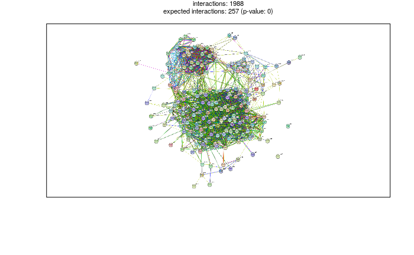

```r
stringdb$plot_network(s1.mapped)
```

Enrichment

```r
enrichment = stringdb$get_enrichment(s1.mapped)
enrichment %>% dted
```

| category | term | number_of_genes | number_of_genes_in_background | ncbiTaxonId | inputGenes | preferredNames | p_value | fdr | description |
| --- | --- | --- | --- | --- | --- | --- | --- | --- | --- |
| Component | GO.0005623 | 165 | 2818 | 511145 | 511145.b0002,511145.b0003,511145.b0004,511145.b0031,511145.b0032,511145.b0033,511145.b0071,511145.b0072,511145.b0073,511145.b0074,511145.b0077,511145.b0078,511145.b0112,511145.b0159,511145.b0166,51114… | thrA,thrB,thrC,dapB,carA,carB,leuD,leuC,leuB,leuA,ilvI,ilvH,aroP,mtn,dapD,metQ,metI,metN,proB,proA,mmuM,argF,proC,aroL,brnQ,proY,ybaT,folD,pheP,gltL,gltK,gltJ,gltI,asnB,potE,aroG,glnQ,glnP,glnH,rhtA,a… | 2.19e-15 | 8.97e-14 | cell |
| Component | GO.0043190 | 18 | 70 | 511145 | 511145.b0197,511145.b0198,511145.b0199,511145.b0653,511145.b0654,511145.b0810,511145.b0861,511145.b0862,511145.b0864,511145.b1918,511145.b2131,511145.b2307,511145.b2308,511145.b2677,511145.b2678,51114… | metQ,metI,metN,gltK,gltJ,glnP,artM,artQ,artP,yecS,osmF,hisM,hisQ,proV,proW,proX,yhdX,yhdY | 9.39e-09 | 1.92e-07 | ATP-binding cassette (ABC) transporter complex |
| Component | GO.1902494 | 30 | 207 | 511145 | 511145.b0032,511145.b0033,511145.b0071,511145.b0078,511145.b0197,511145.b0198,511145.b0199,511145.b0653,511145.b0654,511145.b0810,511145.b0861,511145.b0862,511145.b0864,511145.b1263,511145.b1264,51114… | carA,carB,leuD,ilvH,metQ,metI,metN,gltK,gltJ,glnP,artM,artQ,artP,trpD,trpE,yecS,hisH,hisF,osmF,hisM,hisQ,cysK,proV,proW,proX,yhdX,yhdY,cysE,ilvN,ilvB | 1.65e-08 | 2.26e-07 | catalytic complex |
| Component | GO.1904949 | 18 | 80 | 511145 | 511145.b0197,511145.b0198,511145.b0199,511145.b0653,511145.b0654,511145.b0810,511145.b0861,511145.b0862,511145.b0864,511145.b1918,511145.b2131,511145.b2307,511145.b2308,511145.b2677,511145.b2678,51114… | metQ,metI,metN,gltK,gltJ,glnP,artM,artQ,artP,yecS,osmF,hisM,hisQ,proV,proW,proX,yhdX,yhdY | 5.57e-08 | 4.57e-07 | ATPase complex |
| Component | GO.0005737 | 87 | 1372 | 511145 | 511145.b0002,511145.b0003,511145.b0004,511145.b0031,511145.b0032,511145.b0033,511145.b0071,511145.b0072,511145.b0073,511145.b0074,511145.b0077,511145.b0078,511145.b0159,511145.b0166,511145.b0242,51114… | thrA,thrB,thrC,dapB,carA,carB,leuD,leuC,leuB,leuA,ilvI,ilvH,mtn,dapD,proB,proA,mmuM,argF,proC,aroL,folD,asnB,aroG,serC,aroA,trpA,trpB,trpD,trpE,cysB,aroD,aroH,hisG,hisD,hisC,hisB,hisH,hisA,hisF,hisI,a… | 1.36e-05 | 6.18e-05 | cytoplasm |
| Component | GO.0005622 | 90 | 1489 | 511145 | 511145.b0002,511145.b0003,511145.b0004,511145.b0031,511145.b0032,511145.b0033,511145.b0071,511145.b0072,511145.b0073,511145.b0074,511145.b0077,511145.b0078,511145.b0159,511145.b0166,511145.b0242,51114… | thrA,thrB,thrC,dapB,carA,carB,leuD,leuC,leuB,leuA,ilvI,ilvH,mtn,dapD,proB,proA,mmuM,argF,proC,aroL,folD,asnB,potE,aroG,serC,aroA,trpA,trpB,trpD,trpE,cysB,aroD,aroH,hisG,hisD,hisC,hisB,hisH,hisA,hisF,h… | 5.99e-05 | 0.00025 | intracellular |
| Component | GO.0055052 | 4 | 8 | 511145 | 511145.b0197,511145.b0198,511145.b0199,511145.b0864 | metQ,metI,metN,artP | 0.0011 | 0.0036 | ATP-binding cassette (ABC) transporter complex, substrate-binding subunit-containing |
| Component | GO.0005948 | 3 | 3 | 511145 | 511145.b0078,511145.b3670,511145.b3671 | ilvH,ilvN,ilvB | 0.0012 | 0.0039 | acetolactate synthase complex |
| Component | GO.1990234 | 7 | 40 | 511145 | 511145.b0078,511145.b2023,511145.b2025,511145.b2414,511145.b3607,511145.b3670,511145.b3671 | ilvH,hisH,hisF,cysK,cysE,ilvN,ilvB | 0.0028 | 0.0064 | transferase complex |
| Component | GO.0032991 | 32 | 437 | 511145 | 511145.b0032,511145.b0033,511145.b0071,511145.b0078,511145.b0197,511145.b0198,511145.b0199,511145.b0653,511145.b0654,511145.b0810,511145.b0861,511145.b0862,511145.b0864,511145.b1263,511145.b1264,51114… | carA,carB,leuD,ilvH,metQ,metI,metN,gltK,gltJ,glnP,artM,artQ,artP,trpD,trpE,yecS,hisH,hisF,osmF,hisM,hisQ,cysK,proV,proW,proX,cysI,cysJ,yhdX,yhdY,cysE,ilvN,ilvB | 0.0024 | 0.0064 | protein-containing complex |

[output cut: 484 more lines]

Sommets voisins d’un ou plusieurs sommets donnés

```r
stringdb$get_neighbors(s1.mapped[1:3])
```

```
 [1] "511145.b0002" "511145.b0002" "511145.b0003" "511145.b0003" "511145.b0004"
 [6] "511145.b0004" "511145.b0005" "511145.b0005" "511145.b0981" "511145.b0981"
[11] "511145.b1002" "511145.b1002" "511145.b1006" "511145.b1006" "511145.b2483"
[16] "511145.b2483" "511145.b3107" "511145.b3107" "511145.b3672" "511145.b3672"
[21] "511145.b3766" "511145.b3766" "511145.b4246" "511145.b4246" "511145.b4558"
[26] "511145.b4558"
```

Interactions entre un ensemble de sommets données

```r
stringdb$get_interactions(s1.mapped)
```

|  | from | to | combined_score |
| --- | --- | --- | --- |
| 1 | 511145.b0001 | 511145.b0002 | 617 |
| 2 | 511145.b0001 | 511145.b0002 | 617 |
| 3 | 511145.b0001 | 511145.b0003 | 608 |
| 4 | 511145.b0001 | 511145.b0003 | 608 |
| 5 | 511145.b0002 | 511145.b0003 | 999 |
| 6 | 511145.b0002 | 511145.b0003 | 999 |
| 7 | 511145.b0001 | 511145.b0004 | 604 |
| 8 | 511145.b0001 | 511145.b0004 | 604 |
| 9 | 511145.b0002 | 511145.b0004 | 999 |
| 10 | 511145.b0002 | 511145.b0004 | 999 |

[output cut: 990 more lines]

## STRINGdb detailed links → neo4j

Chargement sous forme de tibble :

```r
links.detailed = read_delim("stringdb/511145.protein.links.detailed.v11.5.txt.gz", delim=" ", col_types = "ccnnnnnnnn")
links.detailed
```

| protein1 | protein2 | neighborhood | fusion | cooccurence | coexpression | experimental | database | textmining | combined_score |
| --- | --- | --- | --- | --- | --- | --- | --- | --- | --- |
| 511145.b0001 | 511145.b0810 | 0 | 0 | 0 | 0 | 0 | 0 | 162 | 161 |
| 511145.b0001 | 511145.b0946 | 0 | 0 | 0 | 0 | 0 | 0 | 200 | 200 |
| 511145.b0001 | 511145.b4403 | 0 | 0 | 0 | 0 | 0 | 0 | 363 | 363 |
| 511145.b0001 | 511145.b2126 | 0 | 0 | 0 | 0 | 0 | 0 | 231 | 230 |
| 511145.b0001 | 511145.b3769 | 0 | 0 | 0 | 0 | 0 | 0 | 299 | 299 |
| 511145.b0001 | 511145.b0943 | 0 | 0 | 0 | 0 | 0 | 0 | 163 | 163 |
| 511145.b0001 | 511145.b0075 | 0 | 0 | 0 | 0 | 0 | 0 | 619 | 619 |
| 511145.b0001 | 511145.b1002 | 0 | 0 | 0 | 0 | 0 | 0 | 239 | 238 |
| 511145.b0001 | 511145.b2023 | 0 | 0 | 0 | 0 | 0 | 0 | 297 | 297 |
| 511145.b0001 | 511145.b3646 | 0 | 0 | 0 | 0 | 0 | 0 | 239 | 238 |

[output cut: 990 more lines]

C’est la **colonne coexpression** qui nous intéresse pour commencer.

Génération des fichiers CSV pour l’import

```r
links.detailed %>%
  filter(coexpression>0 & protein1 < protein2) %>%
  select(protein1, protein2, coexpression) %>%
  mutate(organism=str_extract(protein1, '^\\d+'), id1=str_extract(protein1, 'b\\d+'), id2=str_extract(protein2, 'b\\d+')) %>%
  select(organism:id2,coexpression) %>%
  write_csv("import/string.coexpression.csv") # mettre ce fichier dans l'import de Neo4J
```

Import dans neo4j

```r
'
LOAD CSV WITH HEADERS FROM "file:///string.coexpression.csv" AS line
MATCH (g1:Gene),(g2:Gene)
WHERE g1.id=line.id1 AND g2.id=line.id2
WITH g1,g2, toInteger(line.coexpression) AS value
MERGE (g1)-[:STRINGdb {coexpression: value}]-(g2)
'  %>% cypher
```

Vérification

```r
'MATCH ()-[r:STRINGdb]-() RETURN count(r)' %>% cypher %>% unlist
```

[output not shown]

### Autres liens à intégrer

# On recupere les pairs de gènes dont le score de co-expression est superieur à 400

```r
coex = "MATCH (g1:Gene)-[r:STRINGdb]-(g2:Gene) WHERE r.coexpression>=400 RETURN g1.id, g2.id, r.coexpression" %>% cypher
tibble(id1=coex$g1.id$value, id2=coex$g2.id$value, coexpression=coex$r.coexpression$value)
```

| id1 | id2 | coexpression |
| --- | --- | --- |
| b0002 | b3433 | 515 |
| b0002 | b2319 | 407 |
| b0002 | b0004 | 974 |
| b0002 | b0003 | 922 |
| b0003 | b0002 | 922 |
| b0003 | b3940 | 419 |
| b0003 | b3433 | 673 |
| b0003 | b0004 | 986 |
| b0003 | b2329 | 425 |
| b0003 | b2319 | 607 |

[output cut: 990 more lines]

#retrieval des pairs co-exprimés

```r
g.coexpr = 'MATCH p = ()-[r:STRINGdb]-() WHERE r.coexpression>=400 RETURN p'  %>% cypher(type="graph")
g.coexpr$nodes = g.coexpr$nodes %>% unnest_nodes(what="properties")
g.coexpr$nodes %>% dted
```

| id | label | bnumber | strand | rank | taxon_id | end | id1 | begin |
| --- | --- | --- | --- | --- | --- | --- | --- | --- |
| 1 | Gene | b0002 | + | 2 | 511145 | 2799 | b0002 | 336 |
| 3358 | Gene | b3433 | - | 3359 | 511145 | 3574878 | b3433 | 3573774 |
| 2294 | Gene | b2319 | - | 2295 | 511145 | 2436649 | b2319 | 2435635 |
| 3 | Gene | b0004 | + | 4 | 511145 | 5020 | b0004 | 3733 |
| 2 | Gene | b0003 | + | 3 | 511145 | 3733 | b0003 | 2800 |
| 3859 | Gene | b3940 | + | 3860 | 511145 | 4132267 | b3940 | 4129834 |
| 2304 | Gene | b2329 | - | 2305 | 511145 | 2447473 | b2329 | 2446387 |
| 3605 | Gene | b3670 | - | 3606 | 511145 | 3851092 | b3670 | 3850801 |
| 1236 | Gene | b1261 | - | 1237 | 511145 | 1318415 | b1261 | 1317221 |
| 79 | Gene | b0078 | + | 80 | 511145 | 87848 | b0078 | 87356 |

[output cut: 1855 more lines]

```r
g.coexpr$relationships = g.coexpr$relationships %>%
  unnest_relationships %>%
  select(startNode, endNode, type, everything()) %>%
  mutate(coexpression = unlist(coexpression))
g.coexpr$relationships %>% dted
```

| startNode | endNode | type | id | coexpression |
| --- | --- | --- | --- | --- |
| 1 | 3358 | STRINGdb | 81996 | 515 |
| 1 | 2294 | STRINGdb | 82176 | 407 |
| 1 | 3 | STRINGdb | 81979 | 974 |
| 1 | 2 | STRINGdb | 82104 | 922 |
| 2 | 3859 | STRINGdb | 82324 | 419 |
| 2 | 3358 | STRINGdb | 82212 | 673 |
| 2 | 3 | STRINGdb | 82231 | 986 |
| 2 | 2304 | STRINGdb | 82264 | 425 |
| 2 | 2294 | STRINGdb | 82190 | 607 |
| 3 | 3605 | STRINGdb | 82412 | 419 |

[output cut: 9950 more lines]

```r
library(igraph)
igraph.options(vertex.color=NA)
igraph.options(vertex.label.cex=.6) # font size
igraph.options(vertex.label.family='sans')
igraph.options(vertex.size=2)
igraph.options(edge.label.cex=.6)
igraph.options(edge.label.family='sans')
```

```r
g.coexpr = graph_from_data_frame(d=g.coexpr$relationships, directed=F, vertices = g.coexpr$nodes)
g.coexpr
```

```r
plot(g.coexpr, vertex.label=NA, main='coexpression')
```

[output not shown]

Faire de même avec les liens correspondant aux

- interactions protéines–protéines → `experiment`,
- les associations basées sur la conservation des paires de gènes dans le voisinage sur le chromosome dans d’autres génomes → `neighborhood`,
- les associations basées sur la littérature bio-médicale → `textmining`, (que l’on pourra comparer aux identifiants PubMed→Gene )
- les associations basées sur les annotations → `database`, (quele l’on pourra comparer aux liens Keyword→Gene, Pathway→Gene et GOTerm→Gene)
- le score combiné → `combined_score`

Génération des fichiers CSV pour l’import

```r
links.detailed %>%
  filter(protein1 < protein2) %>%
  mutate(organism=str_extract(protein1, '^\\d+'), id1=str_extract(protein1, 'b\\d+'), id2=str_extract(protein2, 'b\\d+')) %>%
  select(organism:id2,experimental, neighborhood, textmining, database, combined_score) %>%
  write_csv("import/string_other.csv") # mettre ce fichier dans l'import de Neo4J
```

```r
'MATCH (n:Gene) return count(n)' %>% cypher %>% unlist
```

```
count(n).value
          4302
```

```r
'
LOAD CSV WITH HEADERS FROM "file:///string_other.csv" AS line
MATCH (g1:Gene),(g2:Gene)
WHERE g1.id=line.id1 AND g2.id=line.id2
WITH g1,g2, toInteger(line.experimental) AS expe,
toInteger(line.neighborhood) AS neigh, toInteger(line.textmining) AS textm, toInteger(line.database) AS db, toInteger(line.combined_score) AS cs
MERGE (g1)-[:STRINGdb {experimental: expe, neighborhood: neigh, textmining: textm, database: db, combined_score: cs}]-(g2)
'  %>% cypher
```

```r
g2 = 'MATCH p = ()-[r:STRINGdb]-() WHERE r.coexpression>=400 OR r.neighborhood>=400 OR r.experimental>=400 RETURN p'  %>% cypher(type="graph")


g2$nodes = g2$nodes %>% unnest_nodes(what="properties")
g2$nodes %>% dted


g2$relationships = g2$relationships %>%
  unnest_relationships %>%
  select(startNode, endNode, type, everything()) %>%
  mutate(coexpression = unlist(coexpression))



g2i = graph_from_data_frame(d=g2$relationships, directed=F, vertices = g2$nodes)
g2i


plot(g2i, vertex.label=NA, main="vous l'appelez comme vous voulez")
```

[output not shown]

## Exploration

- Comparer la co-expression entre les gènes de mêmes opérons et d’opérons différents
- Quelles sont les unités de transcription co-exprimées ?
- Correspondent-elles à certains pathways ? partagent-elles des annotations GO ?

## Génération de matrices de similarité

```r
keyword.mat = keywords %>% unique %>% mutate(true=T)
keyword.mat
```

```r
keyword.tab = keyword.mat %>% pivot_wider(names_from = keyword, values_from = true, values_fill = F) %>% as.data.frame
keyword.tab %>% head
```

Je convertie un tableau avec une col nbumber et une col keyword en ligne bnumber et colonne keywords avec true ou false si le mot clé est là

```r
rownames(keyword.tab) = keyword.tab$bnumber
keyword.tab = keyword.tab %>% select(-bnumber)
keyword.dist = keyword.tab %>% dist(method='binary')
keyword.dist[1:10]
```

```r
keyword.scores = round( (1-keyword.dist) * 1000) %>% as.matrix
keyword.scores[1:10,1:10]
```

A partir des liens Keyword, TUs, Pathway, PubMed et GOTerm, il s’agit de générer des matrices pivots individus(bnumber)–variables(Keyword ou TUs ou …) pour ensuite calculer la distance/similarité entre paires de gènes.

→ Comparer les poids des liens obtenus avec ceux de StringDB.

→ A partir de la matrice Gene-GOTerm, calculer les fréquences d’utilisation des GOTerms, en déduire leur IC (Information Content) et une matrice de similarité sémantique entre paires de GOTerms basée sur la relation MICA (*Maximum Information Common Ancestor*).  
→ A partir de la matrice de similarité sémantique entre GOTerm, en déduire le poids de l’association entre paires de gènes

## Combinaison de matrices de similarité

Calcul du score combiné par StringDB (source: http://version11.string-db.org/help/faq/#how-are-the-scores-computed).

En utilisant la librairie `igraph` et après avoir chargé le graphe $g$ avec les liens de *coexpression*, *neighborhood* et *experiment* à partir de neo4j :

```r
prior=0.041
no_prior = function(x, prior = 0.041) (ifelse(is.na(x), 0, x) / 1000 - prior) / (1-prior)
s_coexp_nop = no_prior(E(g2i)$coexpression)
s_ppi_nop = no_prior(E(g2i)$experimental)
s_neighborhood_nop = no_prior(E(g2i)$neighborhood)
s_tot_nop = 1 - (1 - s_coexp_nop) * (1 - s_ppi_nop) * (1 - s_neighborhood_nop)
E(g2i)$combined_score = round(1000 * (s_tot_nop + prior *(1 - s_tot_nop)))
```

communautés

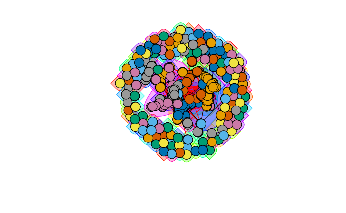

```r
coms = cluster_louvain(g2i, weights=E(g2i)$comnined_score)
plot(coms, g2i, vertex.label=NA)
```